# CS 1675 Final Project

Part iiB Regression models

Teoh Zhixiang

## Load packages and data

```r
library(tidyverse)
df <- readr::read_rds("df.rds")
step_1_df <- readr::read_rds("step_1_df.rds")
step_2_a_df <- readr::read_rds("step_2_a_df.rds")
step_2_b_df <- readr::read_rds("step_2_b_df.rds")
mod_lm_basis <- readr::read_rds("mod_lm_basis.rds")
mod_lm_step1 <- readr::read_rds("mod_lm_step1.rds")
```

## Overview

1. Exploration
2. **Regression models**
3. Binary classification option b
4. Binary classification option a
5. Interpretation and optimization

This R Markdown file tackles part iiB, specifically using Bayesian linear models to fit the two linear models we previously fit with `lm()`, in part iiA.

iiA. Regression models - `lm()` **iiB. Regression models - Bayesian** iiC. Regression models - Models with Resampling

We will use the `rstanarm` package’s `stan_lm()` function to fit full Bayesian linear models, with syntax similar to the `lm()` function.

```r
library(rstanarm)
```

## Regression models - Bayesian

### Fitting `response_1` to all step 1 inputs

Let’s first fit a linear model for `response_1`, using a linear relationship with all step 1 inputs, as we did in part iiA.

First, see frequentist estimated coefficients using `lm()` model:

```r
round(coef(mod_lm_step1), 3)
```

```
## (Intercept)        xAA2        xBB2        xBB3        xBB4         x01
##     180.492       0.432      -2.408      -7.868      -1.273       0.861
##         x02         x03         x04         x05         x06
##      -4.137       0.065       0.037      -0.003      -0.158
```

Use `stan_lm()` to fit Bayesian linear model:

```r
post_stanlm_step1 <- stan_lm(response_1 ~ .,
                            data = step_1_df,
                            prior = R2(what = "mode", location = 0.5),
                            seed = 12345)
post_stanlm_step1
```

```
## stan_lm
##  family:       gaussian [identity]
##  formula:      response_1 ~ .
##  observations: 2013
##  predictors:   11
## ------
##             Median MAD_SD
## (Intercept) 179.4   28.0
## xAA2          0.4    0.2
## xBB2         -2.4    0.2
## xBB3         -7.8    0.2
## xBB4         -1.3    0.3
## x01           0.9    0.1
## x02          -4.1    0.2
## x03           0.1    0.0
## x04           0.0    0.0
## x05           0.0    0.0
## x06          -0.2    0.2
##
## Auxiliary parameter(s):
##               Median MAD_SD
## R2            0.5    0.0
## log-fit_ratio 0.0    0.0
## sigma         3.8    0.1
##
## ------
## * For help interpreting the printed output see ?print.stanreg
## * For info on the priors used see ?prior_summary.stanreg
```

```r
round(coef(post_stanlm_step1), 3)
```

```
## (Intercept)        xAA2        xBB2        xBB3        xBB4         x01
##     179.366       0.429      -2.399      -7.826      -1.271       0.858
##         x02         x03         x04         x05         x06
##      -4.115       0.064       0.037      -0.004      -0.155
```

### Fitting `response_1` to basis function

Let’s fit a linear model for `response_1`, using a linear relationship with the basis function we defined previously in part iiA.

First, see frequentist estimated coefficients using `lm()` model:

```r
round(coef(mod_lm_basis), 3)
```

```
##                    (Intercept)                           xAA2
##                         44.064                          0.325
##                           xBB2                           xBB3
##                        -20.771                        -96.085
##                           xBB4      splines::ns(x01, df = 2)1
##                        -21.366                        -25.011
##      splines::ns(x01, df = 2)2      splines::ns(x02, df = 2)1
##                         15.460                        -24.719
##      splines::ns(x02, df = 2)2      splines::ns(x03, df = 2)1
##                         -4.968                        -23.922
##      splines::ns(x03, df = 2)2 xBB2:splines::ns(x01, df = 2)1
##                          7.489                         25.215
## xBB3:splines::ns(x01, df = 2)1 xBB4:splines::ns(x01, df = 2)1
##                         68.747                          7.313
## xBB2:splines::ns(x01, df = 2)2 xBB3:splines::ns(x01, df = 2)2
##                         -9.313                        -20.177
## xBB4:splines::ns(x01, df = 2)2 xBB2:splines::ns(x02, df = 2)1
##                         -3.288                          0.505
## xBB3:splines::ns(x02, df = 2)1 xBB4:splines::ns(x02, df = 2)1
##                         24.252                         22.155
## xBB2:splines::ns(x02, df = 2)2 xBB3:splines::ns(x02, df = 2)2
##                         -0.701                         -8.780
## xBB4:splines::ns(x02, df = 2)2 xBB2:splines::ns(x03, df = 2)1
##                         -9.637                          6.866
## xBB3:splines::ns(x03, df = 2)1 xBB4:splines::ns(x03, df = 2)1
##                         62.252                          6.233
## xBB2:splines::ns(x03, df = 2)2 xBB3:splines::ns(x03, df = 2)2
##                         -2.672                        -22.961
## xBB4:splines::ns(x03, df = 2)2
##                         -0.895
```

With `stan_lm()` the linear model is fit using the formula interface, specifying a prior mode for R-squared:

```r
post_stanlm_basis <- stan_lm(response_1 ~ xA + xB*(splines::ns(x01, df = 2) + splines::ns(x02, df = 2) + splines::ns(x03, df = 2)),
                             data = step_1_df,
                             prior = R2(what = "mode", location = 0.5),
                             iter = 4000,
                             seed = 12345)
post_stanlm_basis
```

```
## stan_lm
##  family:       gaussian [identity]
##  formula:      response_1 ~ xA + xB * (splines::ns(x01, df = 2) + splines::ns(x02,
##     df = 2) + splines::ns(x03, df = 2))
##  observations: 2013
##  predictors:   29
## ------
##                                Median MAD_SD
## (Intercept)                     43.9    1.0
## xAA2                             0.3    0.1
## xBB2                           -20.7    1.5
## xBB3                           -95.8    1.4
## xBB4                           -21.3    1.6
## splines::ns(x01, df = 2)1      -24.9    1.0
## splines::ns(x01, df = 2)2       15.4    0.5
## splines::ns(x02, df = 2)1      -24.6    0.9
## splines::ns(x02, df = 2)2       -5.0    0.6
## splines::ns(x03, df = 2)1      -23.8    1.1
## splines::ns(x03, df = 2)2        7.5    0.8
## xBB2:splines::ns(x01, df = 2)1  25.2    1.6
## xBB3:splines::ns(x01, df = 2)1  68.5    1.4
## xBB4:splines::ns(x01, df = 2)1   7.3    1.7
## xBB2:splines::ns(x01, df = 2)2  -9.3    0.7
## xBB3:splines::ns(x01, df = 2)2 -20.1    0.9
## xBB4:splines::ns(x01, df = 2)2  -3.3    0.7
## xBB2:splines::ns(x02, df = 2)1   0.5    1.5
## xBB3:splines::ns(x02, df = 2)1  24.2    1.2
## xBB4:splines::ns(x02, df = 2)1  22.1    1.5
## xBB2:splines::ns(x02, df = 2)2  -0.7    0.7
## xBB3:splines::ns(x02, df = 2)2  -8.8    0.9
## xBB4:splines::ns(x02, df = 2)2  -9.6    0.8
## xBB2:splines::ns(x03, df = 2)1   6.9    1.7
## xBB3:splines::ns(x03, df = 2)1  62.0    1.6
## xBB4:splines::ns(x03, df = 2)1   6.2    2.0
## xBB2:splines::ns(x03, df = 2)2  -2.6    0.9
## xBB3:splines::ns(x03, df = 2)2 -22.9    1.0
## xBB4:splines::ns(x03, df = 2)2  -0.9    1.0
##
## Auxiliary parameter(s):
##               Median MAD_SD
## R2            0.9    0.0
## log-fit_ratio 0.0    0.0
## sigma         1.8    0.0
##
## ------
## * For help interpreting the printed output see ?print.stanreg
## * For info on the priors used see ?prior_summary.stanreg
```

```r
round(coef(post_stanlm_basis), 3)
```

```
##                    (Intercept)                           xAA2
##                         43.917                          0.324
##                           xBB2                           xBB3
##                        -20.718                        -95.758
##                           xBB4      splines::ns(x01, df = 2)1
##                        -21.310                        -24.944
##      splines::ns(x01, df = 2)2      splines::ns(x02, df = 2)1
##                         15.409                        -24.646
##      splines::ns(x02, df = 2)2      splines::ns(x03, df = 2)1
##                         -4.957                        -23.831
##      splines::ns(x03, df = 2)2 xBB2:splines::ns(x01, df = 2)1
##                          7.457                         25.157
## xBB3:splines::ns(x01, df = 2)1 xBB4:splines::ns(x01, df = 2)1
##                         68.529                          7.336
## xBB2:splines::ns(x01, df = 2)2 xBB3:splines::ns(x01, df = 2)2
##                         -9.284                        -20.098
## xBB4:splines::ns(x01, df = 2)2 xBB2:splines::ns(x02, df = 2)1
##                         -3.283                          0.540
## xBB3:splines::ns(x02, df = 2)1 xBB4:splines::ns(x02, df = 2)1
##                         24.177                         22.096
## xBB2:splines::ns(x02, df = 2)2 xBB3:splines::ns(x02, df = 2)2
##                         -0.701                         -8.751
## xBB4:splines::ns(x02, df = 2)2 xBB2:splines::ns(x03, df = 2)1
##                         -9.597                          6.852
## xBB3:splines::ns(x03, df = 2)1 xBB4:splines::ns(x03, df = 2)1
##                         62.029                          6.220
## xBB2:splines::ns(x03, df = 2)2 xBB3:splines::ns(x03, df = 2)2
##                         -2.639                        -22.893
## xBB4:splines::ns(x03, df = 2)2
##                         -0.870
```

### Comparing Bayesian linear models

```r
loo_post_stanlm_basis <- loo(post_stanlm_basis)
loo_post_stanlm_step1 <- loo(post_stanlm_step1)
loo_compare(loo_post_stanlm_basis, loo_post_stanlm_step1)
```

```
##                   elpd_diff se_diff
## post_stanlm_basis     0.0       0.0
## post_stanlm_step1 -1517.0      52.3
```

The Bayesian linear model model using the basis function is the preferred and better one, for its lower LOO Information Criterion (LOOIC) that estimates the expected log predicted density (ELPD) for a new dataset (out-of-sample data). The LOOIC is a Bayesian-equivalent to the Akaike Information Criterion (AIC), that integrates over uncertainty in the parameters of the posterior distribution.

### Visualize posterior distributions on coefficients for basis model

First visualize the coefficient estimates, similar to in part iiA.

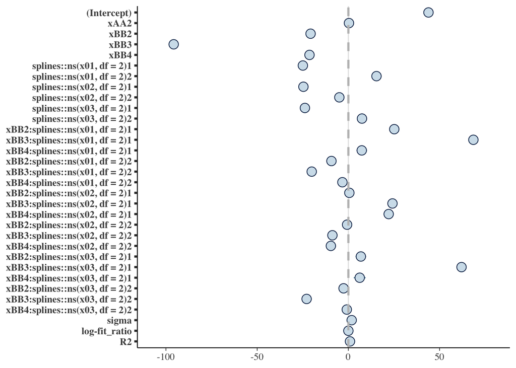

```r
plot(post_stanlm_basis)  +
  geom_vline(xintercept = 0, color = "grey", linetype = "dashed", size = 1.)
```

Next we plot the coefficient distributions.

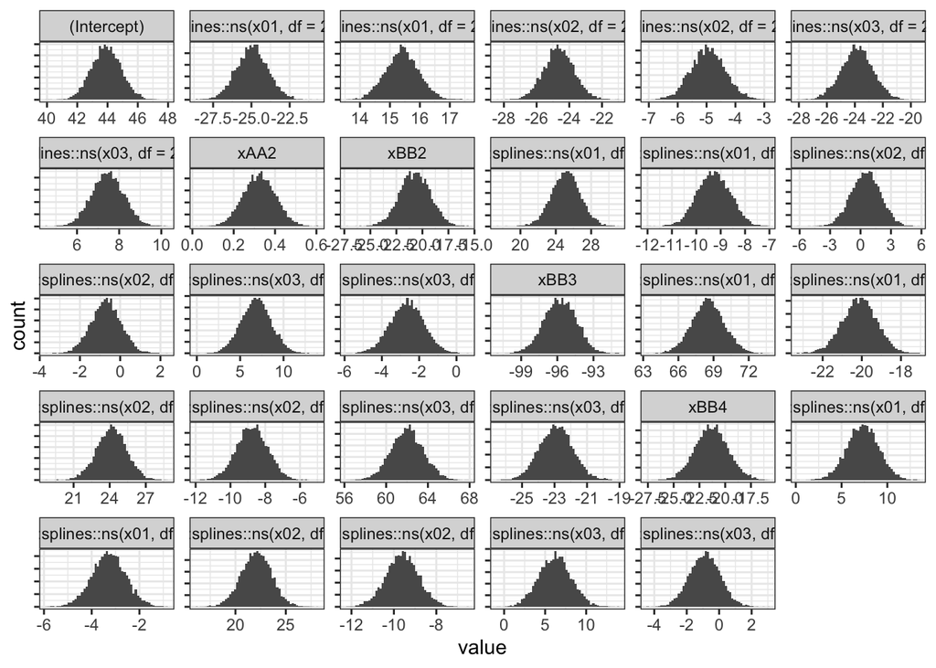

```r
as.data.frame(post_stanlm_basis) %>% tibble::as_tibble() %>%
  select(names(post_stanlm_basis$coefficients)) %>%
  tibble::rowid_to_column("post_id") %>%
  tidyr::gather(key = "key", value = "value", -post_id) %>%
  ggplot(mapping = aes(x = value)) +
  geom_histogram(bins = 55) +
  facet_wrap(~key, scales = "free") +
  theme_bw() +
  theme(axis.text.y = element_blank())
```

### Comparing uncertainty in noise

Display the maximum likelihood estimate of the noise, or residual standard error, $\sigma$ obtained using `lm()` for the basis model:

```r
SSE <- sum(mod_lm_basis$residuals**2)
n <- length(mod_lm_basis$residuals)

mle_sigma <- sqrt(SSE/(n - length(mod_lm_basis$coefficients)))

mle_sigma
```

```
## [1] 1.796463
```

Display the posterior uncertainty on $\sigma$:

```r
# noise quantiles
as.data.frame(post_stanlm_basis) %>% tibble::as_tibble() %>%
  select(sigma) %>%
  pull() %>%
  quantile(c(0.05, 0.5, 0.95))
```

```
##       5%      50%      95%
## 1.760379 1.806893 1.854134
```

```r
# noise 95% posterior interval
posterior_interval(post_stanlm_basis, prob = 0.95, pars = "sigma")
```

```
##           2.5%    97.5%
## sigma 1.751596 1.864234
```

Visualize the posterior distribution on $\sigma$, indicating MLE of $\sigma$ from part iiA:

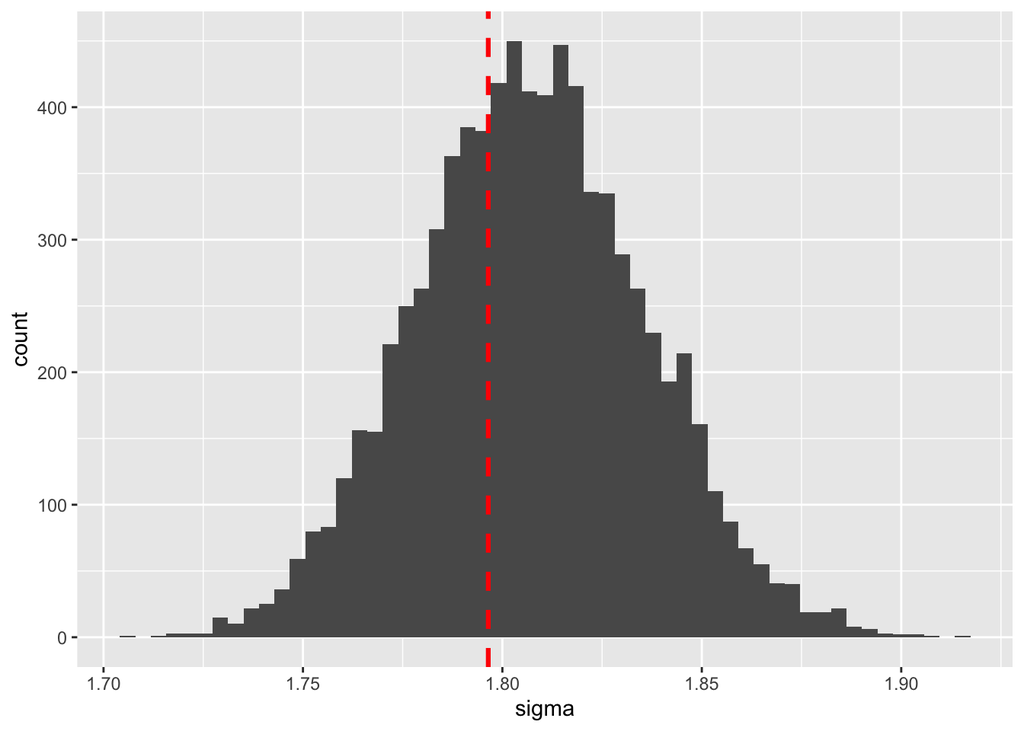

```r
as.data.frame(post_stanlm_basis) %>% tibble::as_tibble() %>%
  ggplot(mapping = aes(x = sigma)) +
  geom_histogram(bins = 55) +
  geom_vline(xintercept = mle_sigma,
             color = "red", linetype = "dashed", size = 1.1)
```

The MLE of $\sigma$ falls within the 95% posterior uncertainty interval, near the mode.

## Saving

```r
post_stanlm_basis %>% readr::write_rds("post_stanlm_basis.rds")
post_stanlm_step1 %>% readr::write_rds("post_stanlm_step1.rds")
```